# Women's E-Commerce Clothing Reviews Data Exploration

## Preliminary Wrangling

> This is a Women’s Clothing E-Commerce dataset revolving around the reviews written by customers. Its nine supportive features offer a great environment to parse out the text through its multiple dimensions. Because this is real commercial data, it has been anonymized, and references to the company in the review text and body have been replaced with “retailer”. This dataset was downloaded from [nicapotato - Kaggle](https://www.kaggle.com/nicapotato/womens-ecommerce-clothing-reviews/version/1)

```python
# import all packages and set plots to be embedded inline
import numpy as np
import pandas as pd
import matplotlib.pyplot as plt
import seaborn as sb

%matplotlib inline
```

> Load in your dataset and describe its properties through the questions below. Try and motivate your exploration goals through this section.

```python
df = pd.read_csv('Womens Clothing E-Commerce Reviews.csv', index_col=0)
df.sample(5)
```

|  | Clothing ID | Age | Title | Review Text | Rating | Recommended IND | Positive Feedback Count | Division Name | Department Name | Class Name |
| --- | --- | --- | --- | --- | --- | --- | --- | --- | --- | --- |
| 8969 | 940 | 36 | Worked well for me so far! | I never owned an 'older' version, so nothing t... | 5 | 1 | 0 | General | Tops | Sweaters |
| 2427 | 939 | 39 | NaN | Beautiful jacket and i got lots of compliments... | 1 | 1 | 0 | General | Tops | Sweaters |
| 9624 | 872 | 23 | NaN | NaN | 5 | 1 | 0 | General Petite | Tops | Knits |
| 9599 | 826 | 48 | Not for me | The mustard colour was much stronger than it s... | 3 | 0 | 0 | General | Tops | Blouses |
| 903 | 861 | 48 | This is not red! | I was looking for a shirt of this style. i tho... | 3 | 0 | 0 | General | Tops | Knits |

```python
df.shape[0]
```

```
23486
```

```python
df.isnull().sum()
```

```
Clothing ID                   0
Age                           0
Title                      3810
Review Text                 845
Rating                        0
Recommended IND               0
Positive Feedback Count       0
Division Name                14
Department Name              14
Class Name                   14
dtype: int64
```

```python
df = df.dropna()
df.isnull().sum()
```

```
Clothing ID                0
Age                        0
Title                      0
Review Text                0
Rating                     0
Recommended IND            0
Positive Feedback Count    0
Division Name              0
Department Name            0
Class Name                 0
dtype: int64
```

```python
df.shape[0]
```

```
19662
```

```python
df.info()
```

```
<class 'pandas.core.frame.DataFrame'>
Int64Index: 19662 entries, 2 to 23485
Data columns (total 10 columns):
 #   Column                   Non-Null Count  Dtype
---  ------                   --------------  -----
 0   Clothing ID              19662 non-null  int64
 1   Age                      19662 non-null  int64
 2   Title                    19662 non-null  object
 3   Review Text              19662 non-null  object
 4   Rating                   19662 non-null  int64
 5   Recommended IND          19662 non-null  int64
 6   Positive Feedback Count  19662 non-null  int64
 7   Division Name            19662 non-null  object
 8   Department Name          19662 non-null  object
 9   Class Name               19662 non-null  object
dtypes: int64(5), object(5)
memory usage: 1.7+ MB
```

```python
# The Clothing ID column should be string using map(str) function
df['Clothing ID']= df['Clothing ID'].map(str)

df.info()
```

```
<class 'pandas.core.frame.DataFrame'>
Int64Index: 19662 entries, 2 to 23485
Data columns (total 10 columns):
 #   Column                   Non-Null Count  Dtype
---  ------                   --------------  -----
 0   Clothing ID              19662 non-null  object
 1   Age                      19662 non-null  int64
 2   Title                    19662 non-null  object
 3   Review Text              19662 non-null  object
 4   Rating                   19662 non-null  int64
 5   Recommended IND          19662 non-null  int64
 6   Positive Feedback Count  19662 non-null  int64
 7   Division Name            19662 non-null  object
 8   Department Name          19662 non-null  object
 9   Class Name               19662 non-null  object
dtypes: int64(4), object(6)
memory usage: 1.7+ MB
```

```python
#Check if there is an invalid age (=< 0)
df.Age.min()
```

```
18
```

```python
df.Rating.value_counts()
```

```
5    10858
4     4289
3     2464
2     1360
1      691
Name: Rating, dtype: int64
```

### What is the structure of your dataset?

> This dataset includes 19662 non-null rows and 10 feature variables. Each row corresponds to a customer review, and includes the variables:
> 1. Clothing ID: Integer Categorical variable that refers to the specific piece being reviewed.
> 2. Age: Positive Integer variable of the reviewers age.
> 3. Title: String variable for the title of the review.
> 4. Review Text: String variable for the review body.
> 5. Rating: Positive Ordinal Integer variable for the product score granted by the customer from 1 Worst, to 5 Best.
> 6. Recommended IND: Binary variable stating where the customer recommends the product where 1 is recommended, 0 is not recommended.
> 7. Positive Feedback Count: Positive Integer documenting the number of other customers who found this review positive.
> 8. Division Name: Categorical name of the product high level division.
> 9. Department Name: Categorical name of the product department name.
> 10. Class Name: Categorical name of the product class name.

### What is/are the main feature(s) of interest in your dataset?

> 1. What is the best clothing class, department, and division that have the highest rating reviews?
> 2. What age are customers who recommend a product?
> 3. Do customers most likely write high-rating reviews? Does the company satisfy its customers?
> 4. What are the most frequent words in the reviews?
> 5. Which clothing classes have more high-rating reviews?

### What features in the dataset do you think will help support your investigation into your feature(s) of interest?

> Most of the features are helpful, especially: Age, Rating, Recommended IND, Positive Feedback Count, Division Name, Department Name, and Class Name.

## Univariate Exploration

### Key Insights:

> The company seems to satisfy their customers since they tend to write 5 rating reviews, 82% of them recommended the products, and the most frequent words in the reviews are positive.

### Rating

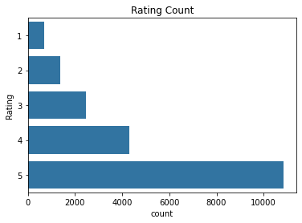

```python
# Plot the Rating on a Horizontal bar chart

# The `color_palette()` returns the the current / default palette as a list of RGB tuples.
# Each tuple consists of three digits specifying the red, green, and blue channel values to specify a color.
# Choose the first tuple of RGB colors
base_color = sb.color_palette()[0]
rating_plt = sb.countplot(data = df, y = 'Rating', color= base_color);
rating_plt.set_title('Rating Count');
```

Observations:

> Most customers rate products with 5.

### Recommended IND

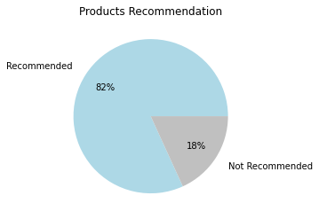

```python
data = df['Recommended IND'].value_counts()
labels = ['Recommended' , 'Not Recommended']
colors = ['lightblue','silver']
# Show percentage position reference: https://stackoverflow.com/questions/21572870/matplotlib-percent-label-position-in-pie-chart
plt.pie(data, labels=labels, colors=colors, autopct='%1.0f%%', pctdistance=0.7, labeldistance=1.2)
plt.title('Products Recommendation')
plt.show()
```

Observations:

> 82% customers recommended the products.

### Age

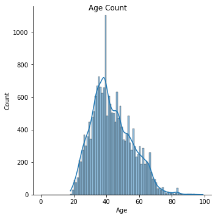

```python
# Plot the Age on a histogram
bin_edges = np.arange(0, df.Age.max()+1, 1)

age_plt = sb.displot(df.Age, bins = bin_edges, kde=True);
age_plt.fig.suptitle('Age Count');
```

Observations:

> The Age feature is slightly right-skewed, but it is expected since most people who use e-commerce are young.

### Division Name

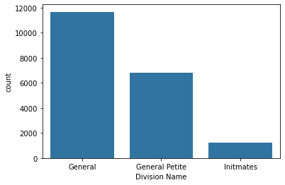

```python
# Plot the Division Name on a Horizontal bar chart

# The `color_palette()` returns the the current / default palette as a list of RGB tuples.
# Each tuple consists of three digits specifying the red, green, and blue channel values to specify a color.
# Choose the first tuple of RGB colors
base_color = sb.color_palette()[0]
sb.countplot(data = df, x = 'Division Name', color= base_color);
```

Observations:

> General is the most reviewed division.

### Department Name

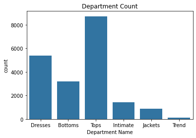

```python
# Plot the Department Name on a Horizontal bar chart

# The `color_palette()` returns the the current / default palette as a list of RGB tuples.
# Each tuple consists of three digits specifying the red, green, and blue channel values to specify a color.
# Choose the first tuple of RGB colors
base_color = sb.color_palette()[0]
dep_plt = sb.countplot(data = df, x = 'Department Name', color= base_color);
dep_plt.set_title('Department Count');
```

Observations:

> Tops are the most reviewd department.

### Class Name

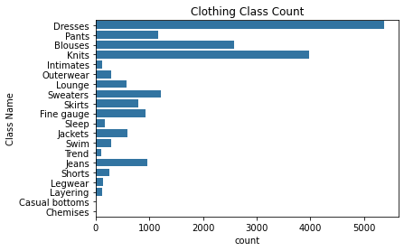

```python
# Plot the Class Name on a Horizontal bar chart

# The `color_palette()` returns the the current / default palette as a list of RGB tuples.
# Each tuple consists of three digits specifying the red, green, and blue channel values to specify a color.
# Choose the first tuple of RGB colors
base_color = sb.color_palette()[0]
class_plt = sb.countplot(data = df, y = 'Class Name', color= base_color);
class_plt.set_title('Clothing Class Count');
```

Observations:

> Dresses is the most reviewed product class.

### Positive Feedback Count

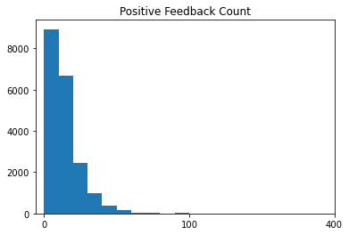

```python
# Plot the Positive Feedback Count on a histogram
#
def sqrt_trans(x, inverse = False):
    """ transformation helper function """
    if not inverse:
        return np.sqrt(x)
    else:
        return x ** 2

# Bin resizing, to transform the x-axis
bin_edges = np.arange(0, sqrt_trans(df['Positive Feedback Count'].max())+1, 1)

# Plot the scaled data
plt.hist(df['Positive Feedback Count'].apply(sqrt_trans), bins = bin_edges)

# Identify the tick-locations
tick_locs = np.arange(0, sqrt_trans(df['Positive Feedback Count'].max())+10, 10)

# Apply x-ticks
plt.xticks(tick_locs, sqrt_trans(tick_locs, inverse = True).astype(int));
plt.title('Positive Feedback Count');
```

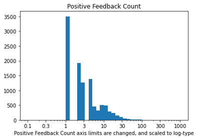

```python
# Get the ticks for bins between [0 - maximum weight]
bins = 10 ** np.arange(-1, 3+0.1, 0.1)

# Generate the x-ticks you want to apply
ticks = [0.1, 0.3, 1, 3, 10, 30, 100, 300, 1000]
# Convert ticks into string values, to be displaye dlong the x-axis
labels = ['{}'.format(v) for v in ticks]

# Plot the histogram
plt.hist(data=df, x='Positive Feedback Count', bins=bins);

# The argument in the xscale() represents the axis scale type to apply.
# The possible values are: {"linear", "log", "symlog", "logit", ...}
plt.xscale('log')

# Apply x-ticks
plt.xticks(ticks, labels);
plt.xlabel('Positive Feedback Count axis limits are changed, and scaled to log-type');
plt.title('Positive Feedback Count');
```

Observations:

> The Positive Feedback Count feature is highly right-skewed.

### Review Text (Word Cloud)

```python
# The wordcloud library is the one responsible for creating WorldClouds.
# It can be a little tricky to install.
# If you only need it for plotting a basic WordCloud, then running one of the commands below would be sufficient.
!pip install wordcloud
```

```python
# Word cloud is a technique for visualising frequent words in a text where the size of the words represents their frequency.
# References:
# - https://towardsdatascience.com/simple-wordcloud-in-python-2ae54a9f58e5
# - https://re-thought.com/creating-wordclouds-in-python/

# Import package
from wordcloud import WordCloud, STOPWORDS

# Create a text list of all words in column bloom.
text = " ".join(review for review in df['Review Text'].astype(str))

# Print how many words are in the text list that was just created from the Pandas column.
print ("There are {} words in the combination of all cells in column Review Text.".format(len(text)))
```

```
There are 6280923 words in the combination of all cells in column Review Text.
```

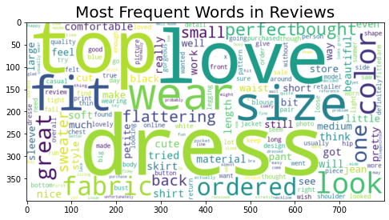

```python
# Create a list of stop words
stopwords = set(STOPWORDS)

# Generate a WordCloud image
wordcloud = WordCloud(stopwords=stopwords, background_color="white", width=800, height=400).generate(text)

# It is time to display the WordCloud in the notebook using matplotlib.
plt.axis("off")
plt.figure(figsize=[8, 8])
plt.tight_layout()
# Use the argument interpolation="bilinear" to make the displayed image appear more smoothly.
plt.imshow(wordcloud, interpolation='bilinear')
plt.title('Most Frequent Words in Reviews', fontsize=20);

plt.show()
```

Observations:

> 1. The most frequent words in reviews are 'dress' and 'love'.
> 2. The frequent words in the reviews are positive.

### Discuss the distribution(s) of your variable(s) of interest. Were there any unusual points? Did you need to perform any transformations?

> There are high values (outliers); however, I won't remove them to avoid bias and I'm interested in these high values too.

### Of the features you investigated, were there any unusual distributions? Did you perform any operations on the data to tidy, adjust, or change the form of the data? If so, why did you do this?

> Not really, the positive feedback count is right-skewed but there's no need to fix it because of the previous point.

## Bivariate Exploration

### Key Insights:

> - The best clothing class that had the highest rating is 'Dresses'.
> - The best clothing department that had the highest rating is 'Tops'.
> - The best clothing division that had the highest rating is 'General'.

### 1. Clothing Class vs Rating

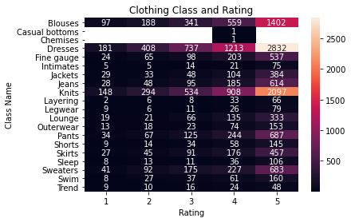

```python
# Use group_by() and size() to get the number of classes and each combination of the two variable levels as a pandas Series
class_counts = df.groupby(['Class Name', 'Rating']).size()

# Use Series.reset_index() to convert a series into a dataframe object
class_counts = class_counts.reset_index(name='count')

# Use DataFrame.pivot() to rearrange the data, to have classes on rows
class_counts = class_counts.pivot(index = 'Class Name', columns = 'Rating', values = 'count')

# Set the fmt to '.0f' for classes that have no rating counts, in order to account for NaNs.
class_plt = sb.heatmap(class_counts, annot = True, fmt = '.0f');

# Change the y-axis labels rotation to make them readable
class_plt.set_yticklabels(class_plt.get_yticklabels(),rotation = 0);

# Set Title
class_plt.set_title('Clothing Class and Rating');
```

Observations:

> The best clothing class that had the highest rating is 'Dresses'

### 2. Clothing Department vs Rating

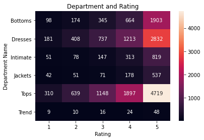

```python
# Use group_by() and size() to get the number of departments and each combination of the two variable levels as a pandas Series
dp_counts = df.groupby(['Department Name', 'Rating']).size()

# Use Series.reset_index() to convert a series into a dataframe object
dp_counts = dp_counts.reset_index(name='count')

# Use DataFrame.pivot() to rearrange the data, to have departments on rows
dp_counts = dp_counts.pivot(index = 'Department Name', columns = 'Rating', values = 'count')

# Set the fmt to '.0f' for departments that have no rating counts, in order to account for NaNs.
dp_plt = sb.heatmap(dp_counts, annot = True, fmt = '.0f');

# Change the y-axis labels rotation to make them readable
dp_plt.set_yticklabels(dp_plt.get_yticklabels(),rotation = 0);

# Set Title
dp_plt.set_title('Department and Rating');
```

Observations:

> The best clothing department that had the highest rating is 'Tops'

### 3. Clothing Division vs Rating

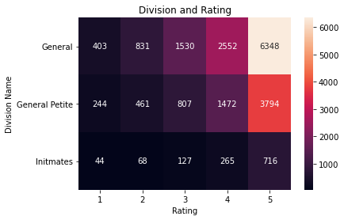

```python
# Use group_by() and size() to get the number of divisions and each combination of the two variable levels as a pandas Series
dv_counts = df.groupby(['Division Name', 'Rating']).size()

# Use Series.reset_index() to convert a series into a dataframe object
dv_counts = dv_counts.reset_index(name='count')

# Use DataFrame.pivot() to rearrange the data, to have divisions class on rows
dv_counts = dv_counts.pivot(index = 'Division Name', columns = 'Rating', values = 'count')

# Set the fmt to '.0f' for divisions that have no rating counts, in order to account for NaNs.
dv_plt = sb.heatmap(dv_counts, annot = True, fmt = '.0f');

# Change the y-axis labels rotation to make them readable
dv_plt.set_yticklabels(dv_plt.get_yticklabels(),rotation = 0);

# Set Title
dv_plt.set_title('Division and Rating');
```

Observations:

> The best clothing division that had the highest rating is 'General'

### 4. Customer's Age vs Recommended Product

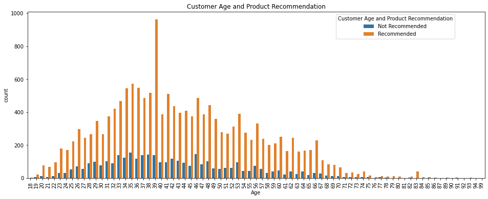

```python
# Change the plot size to make it clear
plt.figure(figsize=(16, 6))

# Change the Recommended IND column to have a meaningful values
df_recommended = df.copy()
df_recommended['Recommended IND'] = df_recommended['Recommended IND'].replace({1: "Recommended", 0: "Not Recommended"})

# Plot the bar chart
age_rec_plt = sb.countplot(data = df_recommended, x = 'Age', hue = 'Recommended IND');

# Change the x-axis labels rotation to make them readable
age_rec_plt.set_xticklabels(age_rec_plt.get_xticklabels(),rotation = 90);

# Set the plot title
age_rec_plt.set_title('Customer Age and Product Recommendation');

# Set the legend title and location
age_rec_plt.legend(title='Customer Age and Product Recommendation', bbox_to_anchor= (0.94, 1));
```

Observations:

> Customers who are in age 39 are most likely to recommend a product.

### Talk about some of the relationships you observed in this part of the investigation. How did the feature(s) of interest vary with other features in the dataset?

> The reviews are most likely high-rated and customers tends to recommend the products. Also, even though the dress clothing class has high rating reviews, the tops department has high rating reviews.

### Did you observe any interesting relationships between the other features (not the main feature(s) of interest)?

> Yes, 39 aged customers are most likely to recommend a product.

## Multivariate Exploration

### Key Insights:

> - Customers found that the dresses reviews were the most positive.
> - 'Intimates', 'Legwear', and 'Layering' clothing classes are most likely to have high rating reviews; however, other customers didn't find these reviews positive.> All of the findings are included in the presentation.

### Age, Positive Feedback Count, and Rating

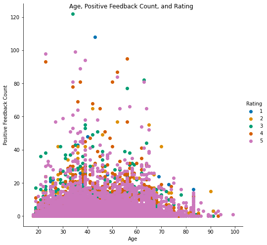

```python
g = sb.FacetGrid(data = df, hue = 'Rating', height = 7,
                 palette = 'colorblind')
g.map(plt.scatter, 'Age', 'Positive Feedback Count')
g.add_legend();

# Set Title
g.fig.suptitle('Age, Positive Feedback Count, and Rating');
```

Observations:

> 1. Customers found that the reviews that written by customers in their mid-30s were positive.
> 2. It is most likely that other customers find that low-rating reviews are positive.

### Clothing Class, Positive Feedback Count, and Rating

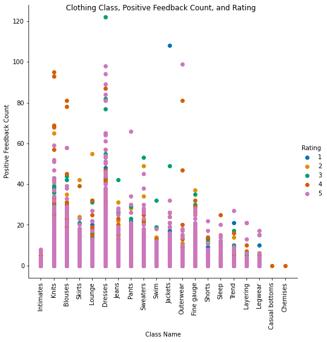

```python
import warnings
warnings.filterwarnings("ignore")

g = sb.FacetGrid(data = df, hue = 'Rating', height = 7,
                 palette = 'colorblind')
g.map(plt.scatter, 'Class Name', 'Positive Feedback Count', alpha=True)
g.add_legend();

# Change the y-axis labels rotation to make them readable

for axes in g.axes.flat:
    _ = axes.set_xticklabels(axes.get_xticklabels(), rotation=90)

# Set Title
g.fig.suptitle('Clothing Class, Positive Feedback Count, and Rating');
```

Observations:

> 1. Customers found that the dresses reviews were the most positive.
> 2. 'Intimates', 'Legwear', and 'Layering' clothing classes are most likely to have high rating reviews; however, other customers didn't find these reviews positive.

### Talk about some of the relationships you observed in this part of the investigation. Were there features that strengthened each other in terms of looking at your feature(s) of interest?

> Customers find that low-rating reviews are more positive than high-rating reviews.

### Were there any interesting or surprising interactions between features?

> Customers didn't find that the most likely clothing classes to have high-rating reviews positive.